# Assignment 2 - Social Network Analysis

## Part I

Start by installing the “igraph” package. Once you have installed igraph, load the package.

Now upload the data file “discipline-data.csv” as a data frame called “D1”. Each row is a disciplinary action from a teacher to a student so the first line shows that teacher “E” sent student “21” to the principal. It also shows the gender of both the teacher and student and the student’s main elective field of study (“major”“) and the field that the teacher instructs in (”t.expertise").

Before you proceed, you will need to change the data type of the student id variable. Since it is a number R will automatically think it is an integer and code it as such (look at the list of variables by clicking on the data frame arrow in the Data pane. Here you will see the letters “int”" next to the stid variable, that stands for integer). However, in this case we are treating the variable as a category, there is no numeric meaning in the variable. So we need to change the format to be a category, what R calls a “factor”. We can do this with the following code:

```r
discipline.data <- read.csv("~/Desktop/hudk4050/assignment2/discipline-data.csv", stringsAsFactors=FALSE)
D1<-data.frame(discipline.data)
D1$stid <- as.factor(D1$stid)
D1
```

```
##    tid stid s.gender s.major t.gender t.expertise
## 1    E   21   female     art   female         art
## 2    A    4     male    math   female     biology
## 3    A   25     male biology   female     biology
## 4    E   15   female english   female         art
## 5    D    1     male biology   female         art
## 6    E    8     male english   female         art
## 7    B    8     male english     male        math
## 8    E   25     male biology   female         art
## 9    A   25     male biology   female     biology
## 10   C   10     male     art     male     biology
## 11   D    4     male    math   female         art
## 12   B   26   female     art     male        math
## 13   D   23   female     art   female         art
## 14   A    3     male     art   female     biology
```

[output cut: 42 more lines]

igraph requires data to be in a particular structure. There are several structures that it can use but we will be using a combination of an “edge list” and a “vertex list”. As you might imagine the edge list contains a list of all the relationships between students and teachers and any characteristics of those edges that we might be interested in. There are two essential variables in the edge list a “from” variable and a “to” variable that descibe the relationships between vertices (a disciplinary action is given “from” and teacher “to” a student). While the vertix list contains all the characteristics of those vertices, in our case gender and major.

So let’s convert our data into an edge list!

First we will isolate the variables that are of interest: tid and stid

```r
library(dplyr)
D2 <- select(D1, tid, stid)

D2
```

```
##    tid stid
## 1    E   21
## 2    A    4
## 3    A   25
## 4    E   15
## 5    D    1
## 6    E    8
## 7    B    8
## 8    E   25
## 9    A   25
## 10   C   10
## 11   D    4
## 12   B   26
## 13   D   23
## 14   A    3
```

[output cut: 42 more lines]

Since our data represnts every time a teacher sends a student to the principal there are multiple rows when the same teacher sends the same student. We want to collapse these into a single row, with a variable that shows how many times a teacher-student pair appears.

```r
D2$stid <- as.character(D2$stid)
EDGE <- count(D2, tid, stid)

names(EDGE) <- c("from", "to", "count")
EDGE
```

```
## # A tibble: 41 x 3
##    from  to    count
##    <chr> <chr> <int>
##  1 A     18        1
##  2 A     2         1
##  3 A     22        1
##  4 A     25        2
##  5 A     3         1
##  6 A     4         2
##  7 A     5         1
##  8 B     1         2
##  9 B     12        1
## 10 B     20        1
## # … with 31 more rows
```

EDGE is your edge list. Now we need to make the vertex list, a list of all the teachers and students and their characteristics in our network.

```r
#First we will separate the teachers from our original data frame
V.TCH <- select(D1, tid, t.gender, t.expertise)
#Remove all the repeats so that we just have a list of each teacher and their characteristics
V.TCH <- unique(V.TCH)
#Add a variable that describes that they are teachers
V.TCH$group <- "teacher"

#Now repeat this process for the students
V.STD <- select(D1, stid, s.gender, s.major)
V.STD <- unique(V.STD)
V.STD$group <- "student"

#Make sure that the student and teacher data frames have the same variables names
names(V.TCH) <- c("id", "gender", "topic", "group")
names(V.STD) <- c("id", "gender", "topic", "group")

#Bind the two data frames together (you will get a warning because the teacher data frame has 5 types of id (A,B,C,D,E) and the student has 25 (1-30), this isn't a problem)
VERTEX <- bind_rows(V.TCH, V.STD)
VERTEX
```

```
##    id gender   topic   group
## 1   E female     art teacher
## 2   A female biology teacher
## 3   D female     art teacher
## 4   B   male    math teacher
## 5   C   male biology teacher
## 6  21 female     art student
## 7   4   male    math student
## 8  25   male biology student
## 9  15 female english student
## 10  1   male biology student
## 11  8   male english student
## 12 10   male     art student
## 13 26 female     art student
## 14 23 female     art student
```

[output cut: 16 more lines]

Now we have both a Vertex and Edge list it is time to plot our graph!

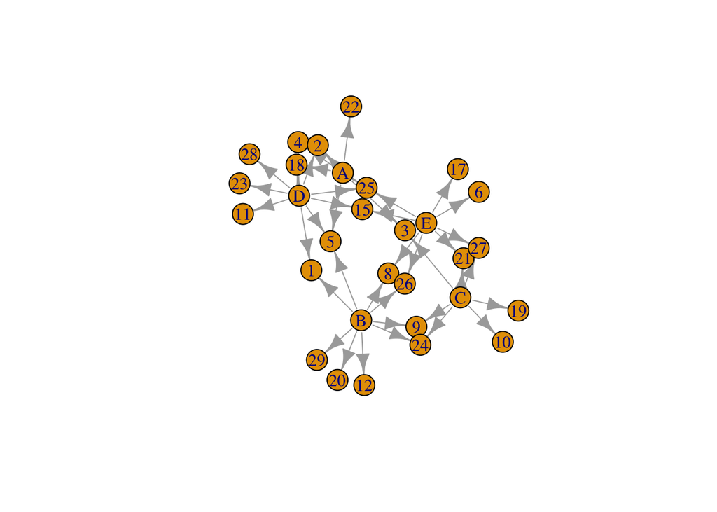

```r
#Load the igraph package

library(igraph)
#First we will make an object that contains the graph information using our two dataframes EDGE and VERTEX. Notice that we have made "directed = TRUE" - our graph is directed since discipline is being given from a teacher to a student.
VERTEX$gender<-as.factor(VERTEX$gender)
g <- graph.data.frame(EDGE, directed=TRUE, vertices=VERTEX)

#Now we can plot our graph using the force directed graphing technique - our old friend Fruchertman-Reingold!

plot(g,layout=layout.fruchterman.reingold)
```

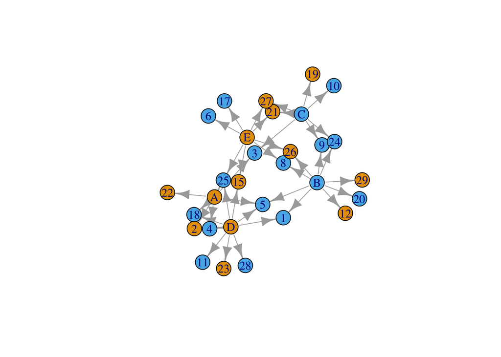

```r
#There are many ways to change the attributes of the graph to represent different characteristics of the newtork. For example, we can color the nodes according to gender.

plot(g,layout=layout.fruchterman.reingold, vertex.color=VERTEX$gender)
```

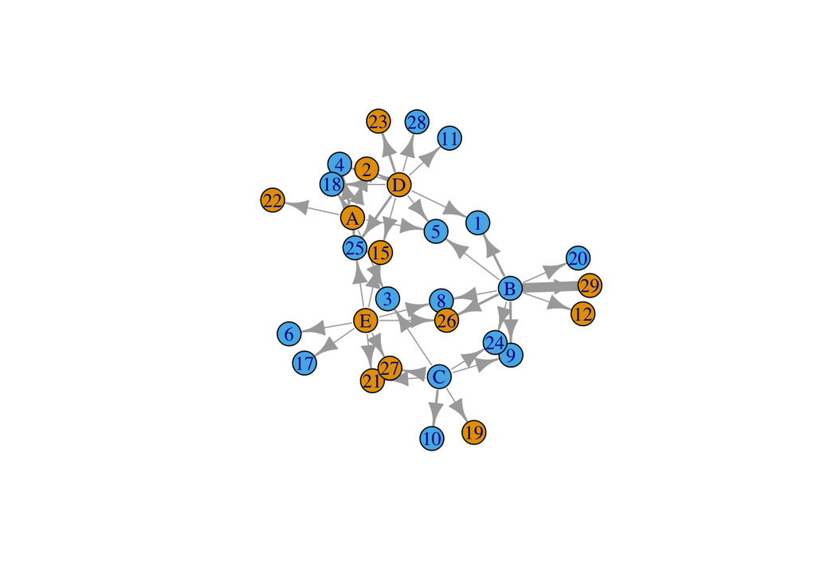

```r
#We can change the thickness of the edge according to the number of times a particular teacher has sent a particular student to the principal.

plot(g,layout=layout.fruchterman.reingold, vertex.color=VERTEX$gender, edge.width=EDGE$count)
```

## Part II

In Part II your task is to [look up](http://igraph.org/r/) in the igraph documentation and create a graph that sizes the student vertices in terms of the number of disciplinary actions they have recieved, and the teachers in terms of the number of disciplinary actions they have given out.

```r
student_sum<- EDGE %>% group_by(to) %>% summarise(sum(count))
names(student_sum)<-c("id","count")
teacher_sum<-EDGE %>%group_by(from)%>%summarise(sum(count))
names(teacher_sum)<-c("id","count")
vertex_new<-bind_rows(student_sum,teacher_sum)
vertex_new
```

```
## # A tibble: 30 x 2
##    id    count
##    <chr> <int>
##  1 1         3
##  2 10        2
##  3 11        1
##  4 12        1
##  5 15        2
##  6 17        1
##  7 18        2
##  8 19        1
##  9 2         2
## 10 20        1
## # … with 20 more rows
```

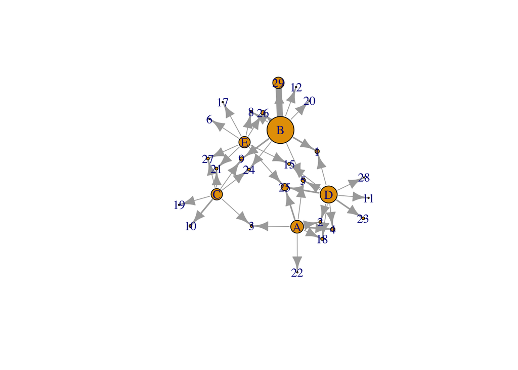

```r
g1 <- graph.data.frame(EDGE, directed=TRUE, vertices=vertex_new)
plot(g1,layout=layout.fruchterman.reingold,
     edge.width=EDGE$count,
     vertex.size = vertex_new$count*1.5)
```

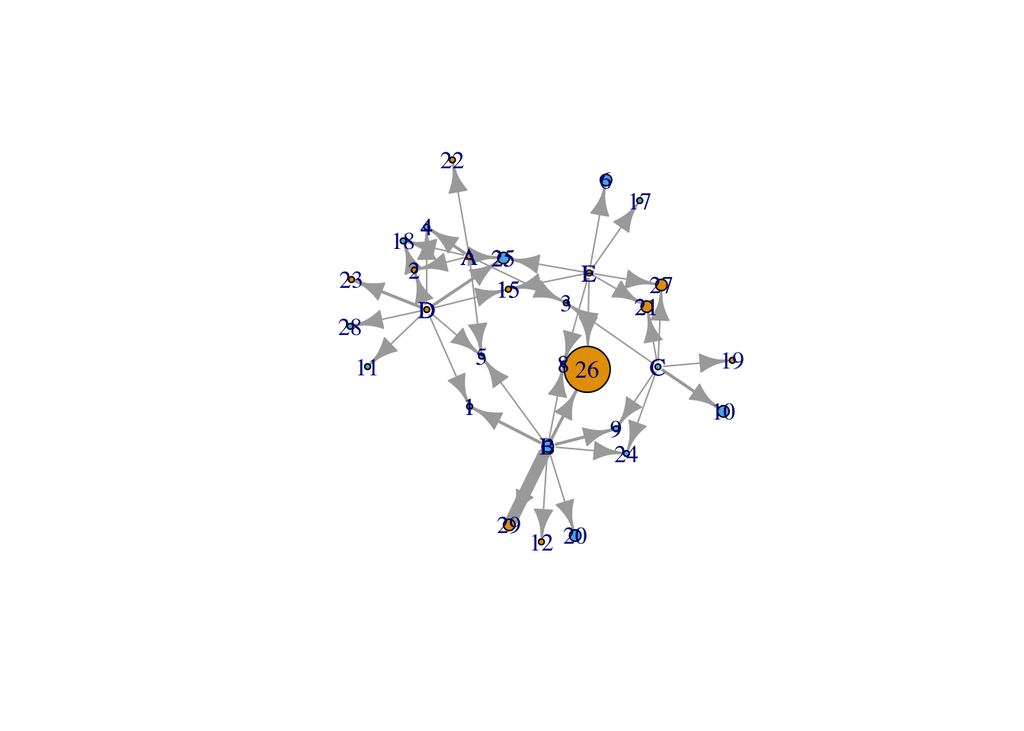

```r
plot(g,layout=layout.fruchterman.reingold, vertex.size=EDGE$count*3,
     vertex.color=VERTEX$gender,
     edge.width=EDGE$count)
```

## Part III

Now practice with data from our class. Please create a **person-network** with the data set hudk4050-classes.csv. To create this network you will need to create a person-class matrix using the tidyr functions and then create a person-person matrix using `t()`. You will then need to plot a matrix rather than a data frame using igraph. data<-select()

```r
hudk4050.classes <- read.csv("~/Desktop/hudk4050/assignment2/hudk4050-classes.txt", header=FALSE, stringsAsFactors=FALSE)
installed.packages("tidyverse")
```

```
##      Package LibPath Version Priority Depends Imports LinkingTo Suggests
##      Enhances License License_is_FOSS License_restricts_use OS_type Archs
##      MD5sum NeedsCompilation Built
```

```r
library(dplyr)
library(tidyr)
```

```r
installed.packages("igraph")
```

```
##      Package LibPath Version Priority Depends Imports LinkingTo Suggests
##      Enhances License License_is_FOSS License_restricts_use OS_type Archs
##      MD5sum NeedsCompilation Built
```

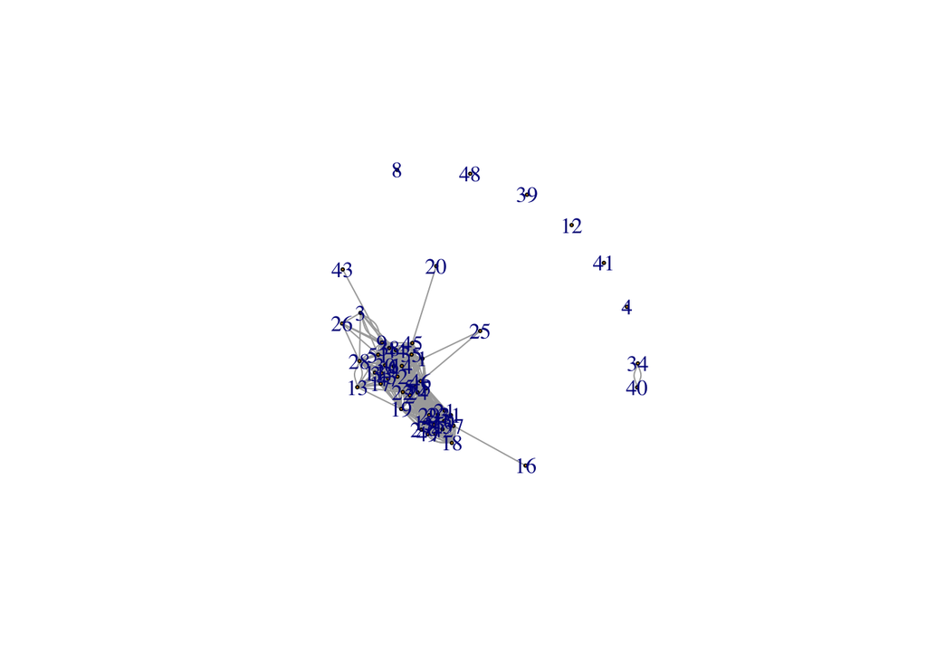

```r
library(igraph)
data<-select(hudk4050.classes,V20,V21,V22,V23,V24,V25,V26)
data <- data.frame(lapply(data, function(x) {
                     gsub(" ", "", x)
     }))
data<-data[-c(1,2,3),]
Name<-data[,1]
#data[,1]<-c(1:53)
colnames(data)<-c("Name","Class 1","Class 2","Class 3","Class 4","Class 5","Class 6")
datatran<-gather(data,"Class Number","ClassName",2:7)
datatran<-datatran[,-2] #remove col class number
datatran<-filter(datatran,ClassName> 0,ClassName!="HUDK4050")
datatran$count<-1
dataaa<-spread(datatran,ClassName,count,fill=0)
#row.names(dataaa)<-Name
dataaa<-dataaa[,-1]
datafinal<-as.matrix(dataaa)
adj<-datafinal %*%t(datafinal)
diag(adj)<-0
g <- graph.adjacency(adj,mode="undirected")
plot(g,layout=layout.fruchterman.reingold, vertex.size=2,margin=0.3)
```

```r
degree<-degree(g)
which.max(degree)
```

```
## [1] 22
```

```r
#Unill3358 has highest degree,Lintong Li
centrality<-betweenness(g)
which.max(centrality) #Uni xz2840 has highest centrality,Xuandi Zhang
```

```
## [1] 46
```

```r
filter(hudk4050.classes,hudk4050.classes$V20=="ll3358")
```

```
##                    V1                  V2         V3           V4  V5  V6
## 1 2019-10-03 15:15:35 2019-10-03 15:18:18 IP Address 160.39.69.28 100 163
##     V7                  V8                V9 V10 V11 V12 V13
## 1 True 2019-10-03 15:18:19 R_33lsAhghE4hAC1u
##                   V14                  V15       V16 V17     V18 V19
## 1 40.8000030517578125 -73.9763031005859375 anonymous  EN Lintong  Li
##      V20       V21       V22       V23       V24 V25 V26 V27
## 1 ll3358 HUDM 5026 HUDK 4052 HUDK 4050 HUDK 4029         Yes
##                                                                                                                    V28
## 1 I consent to allow written materials viewed at an educational setting or at a conference outside of Teachers College
```

```r
filter(hudk4050.classes,hudk4050.classes$V20=="xz2840")
```

```
##                    V1                  V2         V3            V4  V5  V6
## 1 2019-10-03 15:15:31 2019-10-03 15:18:36 IP Address 160.39.69.129 100 184
##     V7                  V8                V9 V10 V11 V12 V13
## 1 True 2019-10-03 15:18:36 R_3Jxb82Gzl9u2H1L
##                   V14                  V15       V16 V17    V18   V19
## 1 40.8000030517578125 -73.9763031005859375 anonymous  EN XUDIAN ZHANG
##      V20       V21       V22       V23       V24       V25 V26 V27
## 1 xz2840 HUDK 4050 HUDM 4125 HUDM 5026 HUDM 5126 QMSS 5015      No
##                                                                                                  V28
## 1 I do not consent to allow written materials viewed outside of Teachers College Columbia University
```

Once you have done this, also [look up](http://igraph.org/r/) how to generate the following network metrics: betweeness centrality and dregree. **Who is the most central person in the network?**

### To Submit Your Assignment

Please submit your assignment by first “knitting” your RMarkdown document into an html file and then comit, push and pull request both the RMarkdown file and the html file.